# Introduction to the earthquakedata package

Paul Visser

2018-01-02

## Aim of the package

The earthquakedata package allows the user to clean and visualise the earthquake data set provided by the [U.S. National Oceanographic and Atmospheric Administration (NOAA)](https://www.ngdc.noaa.gov/nndc/struts/form?t=101650&s=1&d=1). This data set contains information about 5,933 earthquakes over an approximately 4,000 year time span.

Download [here](https://www.ngdc.noaa.gov/nndc/struts/form?t=101650&s=1&d=1)

The earthquakedata package has 6 functions that are exported for use by users and one internal function that is not visible:

- `eq_clean_data()`
- `geom_timeline()`
- `geom_timeline_label()`
- `theme_timeline()`
- `eq_map()`
- `eq_create_label()`

## Clean the data

To be able to visualise the data set properly, it is necessary to clean the data first.

This is achieved by:

- Creating a `DATE` column by uniting `YEAR`, `MONTH` and `DAY` and converting it to the Date class
- Converting the `LATITUDE` and `LONGITUDE` columns to numeric class
- Stripping out the country name (including colon) from the `LOCATION_NAME` column and converting it to title case

```r
clean_data <- readr::read_delim("../earthquakes.tsv.gz",delim = "\t") %>%
  eq_clean_data()
```

## Display the earthquake timeline

The easiest way to display the earthquake data for multiple countries over a large time period is by using a timeline.

To assist the user with this, the `geom_timeline()` function can be used in conjunction with the `ggplot2` package. The `geom_timeline()` function uses the following aesthetics - please note that the user is able to change this to other columns if required

- x = `DATE`
- y = `COUNTRY`
- size = `EQ_PRIMARY`
- colour = `DEATHS`

```r
readr::read_delim("../earthquakes.tsv.gz",delim = "\t") %>%
  eq_clean_data() %>%
  dplyr::filter(COUNTRY == c("USA") & lubridate::year(DATE) >= 2000) %>%
  ggplot() +
    geom_timeline(aes(x = DATE, y = COUNTRY,size = EQ_PRIMARY, colour = DEATHS))
```

The above sample code will display a very basic graph using the default `ggplot2` theme. To allow the user to see some more information and to make the graph a bit more pleasing to the eye, the `geom_timeline_label()` and `theme_timeline()` functions were added to the package.

The `geom_timeline_label()` function adds a vertical line with a text label to identify specific earthquakes easily. To manage the number of labels that will be plotted, the `n_max` parameter is used. It will limit the number of labels to the `n_max` amount and will show the labels for the earthquake events with the highest magnitude.

The `theme_timeline()` function is a modified version of `theme_classic()` and does the following:

- The y axis line, ticks and title are hidden
- The y axis line text is changed to darkgray with size 11 and a right-hand margin of 15
- The x axis line colour black with a thickness of 1
- The x axis text is changed to darkgray with size 11 with a top margin of 3
- The x axis title is size 14 with a top margin of 5
- The plot a title is added and justified horisontally in the middle of the plot
- The legend is positioned at the bottom of the screen

Below is an example that reads the data set, cleans it, filters it to specific countries and dates, plots it, labels the top 5 events and uses the correct theme. Please note that the labels for the legend are added as well along with a title for the plot:

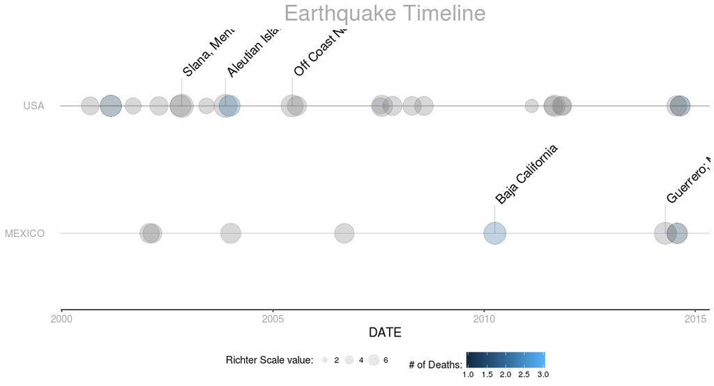

Timeline

```r
readr::read_delim("../earthquakes.tsv.gz",delim = "\t") %>%
  eq_clean_data() %>%
  dplyr::filter(COUNTRY == c("USA","MEXICO") & lubridate::year(DATE) >= 2000) %>%
  ggplot() +
    geom_timeline(aes(x = DATE, y = COUNTRY,size = EQ_PRIMARY, colour = DEATHS)) +
    geom_timeline_label(aes(x = DATE, y = COUNTRY, label = LOCATION_NAME, size = EQ_PRIMARY), n_max = 5) +
    ggtitle("Earthquake Timeline") +
    theme_timeline() +
    labs(size = "Richter Scale value:", colour = "# of Deaths:")
```

## Map the earthquake data

Using the `leaflet` package, it is possible to plot the earthquake information on an interactive map. The user can use the `eq_map()` function to plot the earthquakes on a map. Each earthquake is indicated by a blue circle. The size of the circle on the map is relative to the magnitude of the earthquake it represents. The `annot_col` parameter used by the `eq_map` function reflects a column in the data set that must be displayed when the user clicks on a specific earthquake on the map. The default value is `DATE`

```r
 readr::read_delim("earthquakes.tsv.gz", delim = "\t") %>%
  eq_clean_data() %>%
  dplyr::filter(COUNTRY == "MEXICO" & lubridate::year(DATE) >= 2000) %>%
  eq_map(annot_col = "DATE")
```

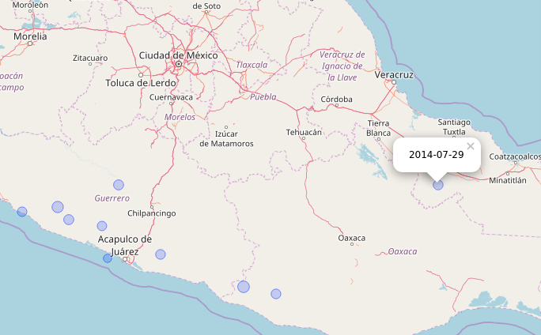

Basic plot

The `eq_create_label()` function is used to provide even more information. It takes the data set as an argument and creates an HTML label that can be displayed on the map as a pop-up. The label consists of the Location, Magnitude and Total deaths. If one of these fields are missing a value, the field is ignored when the label is built

```r
readr::read_delim("earthquakes.tsv.gz",delim = "\t") %>%
  eq_clean_data() %>%
  dplyr::filter(COUNTRY == "MEXICO" & lubridate::year(DATE) >= 2000) %>%
  dplyr::mutate(popup_text = eq_create_label(.))%>%
  eq_map(annot_col = "popup_text")
```

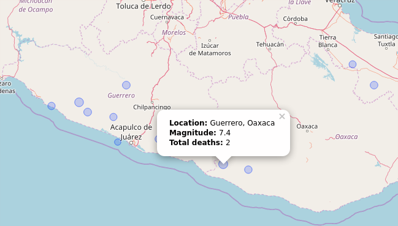

Additional annotation text